# Exploratory Data Analysis - Peer Graded Assignment 2

## Report - National Emissions Inventory Analysis

Fine particulate matter (PM2.5) is an ambient air pollutant for which there is strong evidence that it is harmful to human health. In the United States, the Environmental Protection Agency (EPA) is tasked with setting national ambient air quality standards for fine PM and for tracking the emissions of this pollutant into the atmosphere. Approximatly every 3 years, the EPA releases its database on emissions of PM2.5. This database is known as the National Emissions Inventory (NEI).

For each year and for each type of PM source, the NEI records how many tons of PM2.5 were emitted from that source over the course of the entire year - the data used for this report includes the years 1999, 2002, 2005, and 2008.

We will attempt to answer some exploratory questions herein regarding fine particulate matter emissions with respect to different features (cities - fips, year, motore vehicle-related emissions, type and more).

### 0. Loading Data and Pre-Processing

Let’s begin by loading the necessary libraries for our analysis:

```r
library("dplyr")
library("lubridate")
```

```r
library("ggplot2")
```

Next, we load the data from the NEI and SCC database .rds files:

```r
# Create the data frames as 'df's:
df1 <- readRDS("Source_Classification_Code.rds")
df2 <- readRDS("summarySCC_PM25.rds")
```

### 1. Have total emissions from PM2.5 decreased in the United States from 1999 to 2008?

Using the base plotting system, make a plot showing the total PM2.5 emission from all sources for each of the years 1999, 2002, 2005, and 2008.

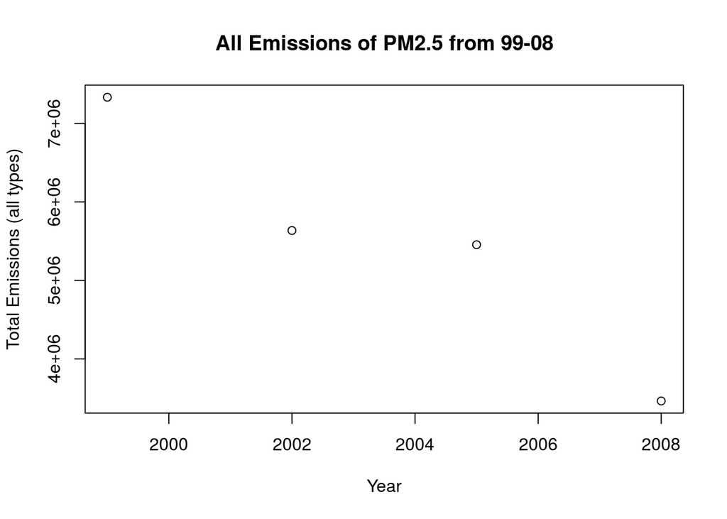

```r
pmPerY <- df2 %>%
  dplyr::filter(Pollutant == "PM25-PRI") %>%
    select(Emissions, year) %>%
      group_by(year) %>%
        summarise(sum(Emissions))

plot(pmPerY, main="All Emissions of PM2.5 from 99-08", xlab="Year", ylab = "Total Emissions (all types)")
```

```r
png(filename="plot1.png")
dev.off()
```

### 2. Have total emissions from PM2.5 decreased in the Baltimore City, Maryland (fips == “24510”) from 1999 to 2008?

Use the base plotting system to make a plot answering this question.

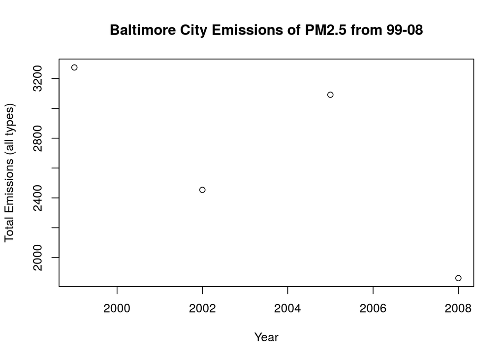

```r
pmPerBmore <- df2 %>%
  dplyr::filter(Pollutant == "PM25-PRI", fips == "24510") %>%
  select(Emissions, year) %>%
  group_by(year) %>%
  summarise(sum(Emissions))

deltaEmiss <- data.frame(diff(as.matrix(pmPerBmore)))

plot(pmPerBmore, main="Baltimore City Emissions of PM2.5 from 99-08", xlab="Year", ylab = "Total Emissions (all types)")
```

```r
png(filename="plot2.png")
dev.off()
```

Emissions decreased from ’99-’02 by 820.2643 units Emissions increased from ’02-’05 by 637.4383 units Emissions decreased from ’05-’08 by 1229.0726 units Emissions decreased from ’99-08 (overall) by 1411.899 units

### 3. Of the four types (point, nonpoint, onroad, nonroad), which of these four sources have seen decreases in emissions from 1999–2008 for Baltimore City?

Which of these four sources have seen decreases in emissions from 1999–2008 for Baltimore City? Which have seen increases in emissions from 1999–2008? Use the ggplot2 to make a plot for this question.

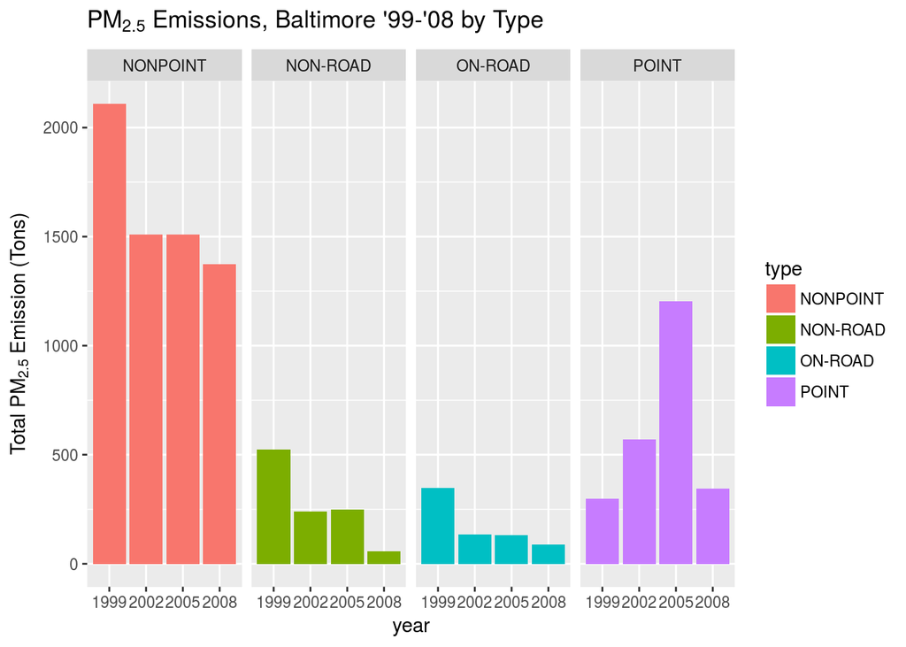

```r
pmBmoreType <- df2 %>%
  dplyr::filter(Pollutant == "PM25-PRI", fips == "24510") %>%
  select(Emissions, type, year) %>%
  group_by(type, year) %>%
  summarise(sum(Emissions))

ggplot(pmBmoreType, aes(factor(year), pmBmoreType$`sum(Emissions)`, fill = type)) +
  geom_bar(stat = "Identity") +
    facet_grid(.~type, scales = "free", space = "free") +
      labs(x="year", y=expression("Total PM"[2.5]*" Emission (Tons)")) +
        labs(title=expression("PM"[2.5]*" Emissions, Baltimore '99-'08 by Type"))
```

```r
png(filename="plot3.png")
dev.off()
```

All but type ‘POINT’ have decreased overall from ’99-’08.

### 4. Across the United States, how have emissions from coal combustion-related sources changed from 1999–2008?

```r
library("stringr")
library("data.table")
```

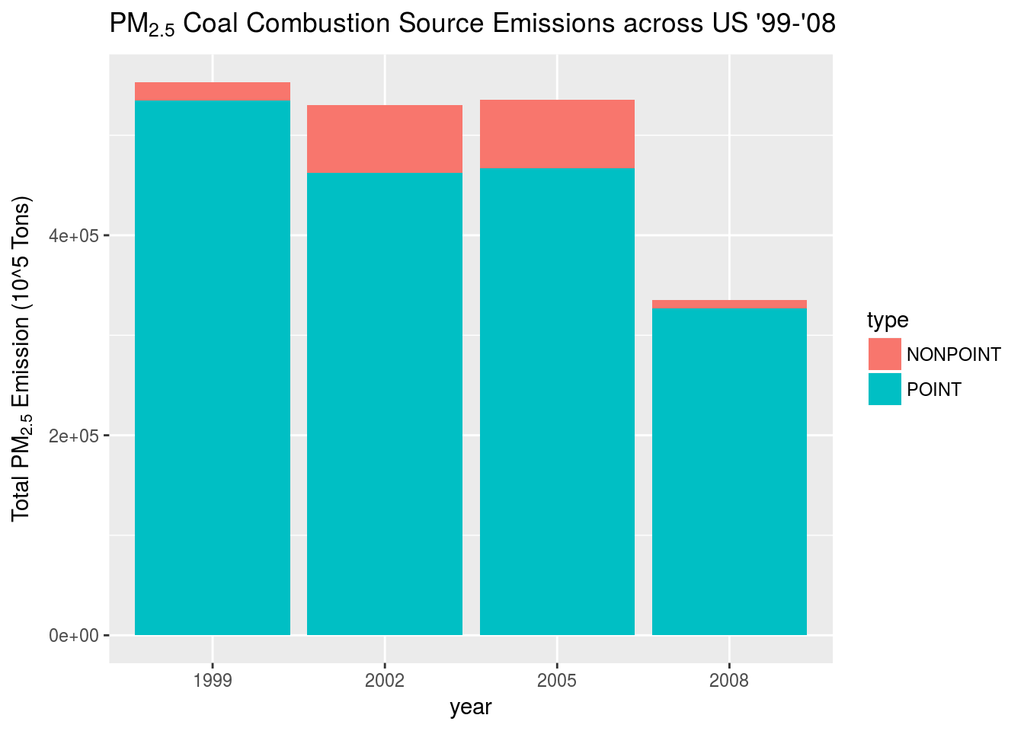

```r
# df1$SCC.Level.One <- str_to_title(df1$SCC.Level.One)
# df1$SCC.Level.Three <- str_to_title(df1$SCC.Level.Three)
coalComb <- df1 %>%
   dplyr::filter(SCC.Level.One %like% "Combustion" & SCC.Level.Three %like% "Coal")
ccDf2 <- subset(df2, df2$SCC %in% coalComb$SCC) %>%
  select(Emissions, type, year) %>%
  group_by(type, year) %>%
  summarise(sum(Emissions))

ggplot(ccDf2, aes(factor(year), ccDf2$`sum(Emissions)`, fill = type)) +
  geom_bar(stat = "Identity") +
  labs(x="year", y=expression("Total PM"[2.5]*" Emission (10^5 Tons)")) +
  labs(title=expression("PM"[2.5]*" Coal Combustion Source Emissions across US '99-'08"))
```

```r
png(filename="plot4.png")
dev.off()
```

### 5. How have emissions from motor vehicle sources changed from 1999–2008 in Baltimore City?

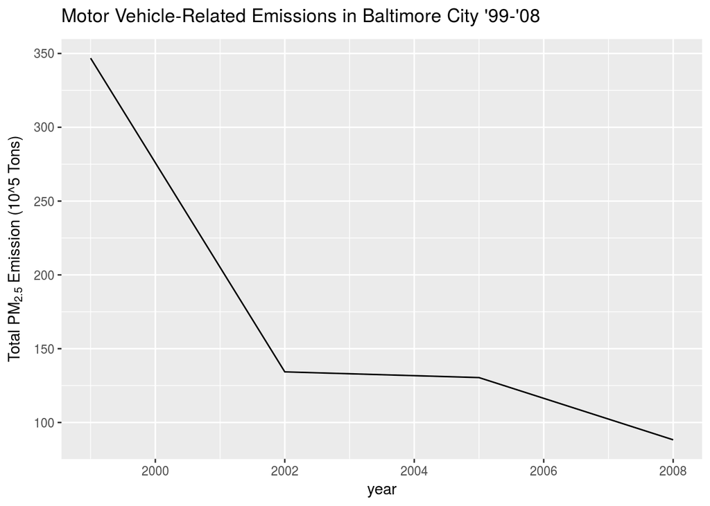

```r
onRoadBmore <- df2 %>%
  dplyr::filter(fips == "24510" & type == "ON-ROAD") %>%
  select(Emissions, fips, year) %>%
  group_by(fips, year) %>%
  summarise(sum(Emissions))

qplot(year, `sum(Emissions)`, data = onRoadBmore, geom = "line") +
  xlab("year") +
  ylab(expression("Total PM"[2.5]*" Emission (10^5 Tons)")) +
  labs(title=expression("Motor Vehicle-Related Emissions in Baltimore City '99-'08"))
```

```r
png(filename="plot5.png")
dev.off()
```

### 6. Compare emissions from motor vehicle sources in Baltimore City with emissions from motor vehicle sources in Los Angeles County, California (fips == 06037).

Which city has seen greater changes over time in motor vehicle emissions?

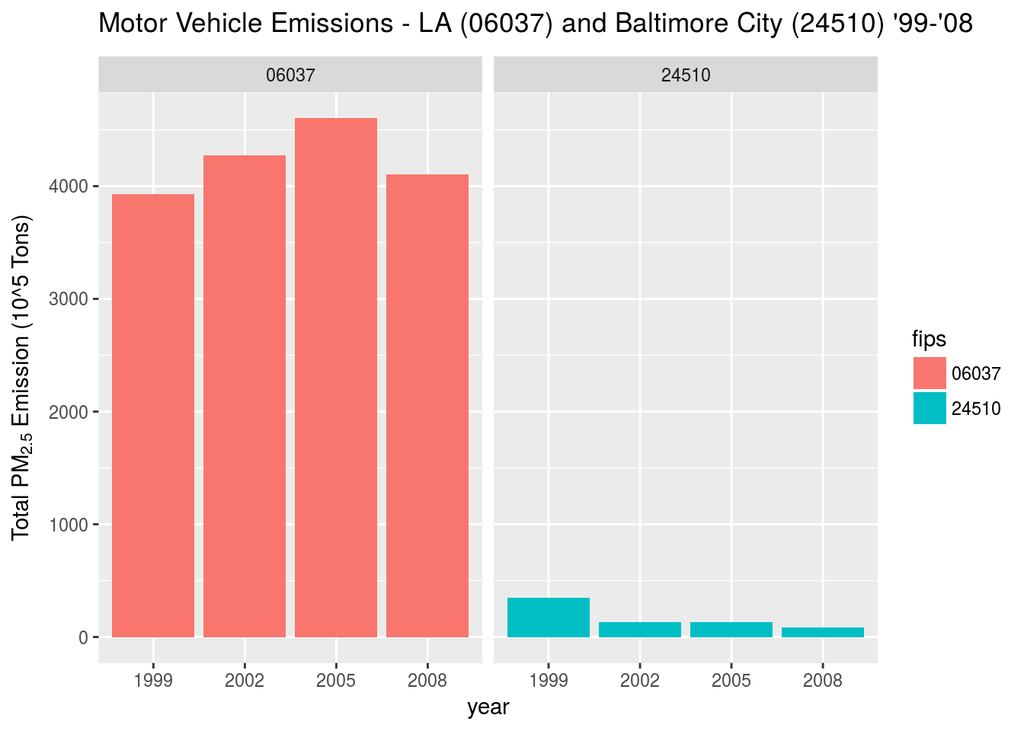

```r
onRoadLa <- df2 %>%
  dplyr::filter(fips == "06037" & type == "ON-ROAD") %>%
  select(Emissions, fips, year) %>%
  group_by(fips, year) %>%
  summarise(sum(Emissions))

compare <- rbind(onRoadBmore, onRoadLa)

ggplot(compare, aes(factor(year), `sum(Emissions)`, fill = fips)) +
  geom_bar(stat = "Identity") +
  facet_grid(. ~ fips) +
  labs(x="year", y=expression("Total PM"[2.5]*" Emission (10^5 Tons)")) +
  labs(title=expression("Motor Vehicle Emissions - LA (06037) and Baltimore City (24510) '99-'08"))
```

```r
png(filename="plot6.png")
dev.off()
```